# Does giving information about labor market and migrant’s education level affect the perceived skills transferability?

William Fernandez, Fernanda Gomes, Cintya Huaire

abril 18, 2022 | 05:13:07 | CEST

# Packages

```r
library(tidyverse) # To use dplyr functions and the pipe operator when needed
library(ggplot2) # To visualize data
library(stargazer) # To format model output
library(fastDummies) # To create dummies
library(vtable) # To create descriptive variable table
```

# Loading Dataset

```r
dta_experiment <- read.csv("final_data.csv", sep = ";")
```

# Processing Dataset

```r
##Cleaning
# excluding unfinished survey
attach(dta_experiment)
newdata <- dta_experiment[ which(FINISHED==1 ),]
detach(dta_experiment)

# removing 3 observations that were not assign to any group, and surveys without consent
newdata <- newdata[ which(newdata$IL02!=" " | newdata$C103 =="I agree"),]

#dropping observations of non students
newdata <- newdata[ which(newdata$A108!="No" ),]

##Transformation and creation of variables
#changing age into numeric
newdata$A101 <- as.numeric(newdata$A101)

regressiondata <- newdata

#creating dummies for descriptive
newdata$europe<- ifelse(newdata$A110=="None of the above",1,0)

newdata_dummy<- fastDummies::dummy_cols(newdata, select_columns = c("A102", "A105","A109"), remove_first_dummy = TRUE)
myvars <- names(newdata_dummy) %in% c("CASE","QUESTNNR","IL01_CP",
                                      "MODE","STARTED","SERIAL", "TIME001", "TIME002", "TIME003",
                                      "TIME004", "TIME005","TIME006", "TIME_SUM", "LASTDATA","C103",
                                      "REF", "MAILSENT", "FINISHED","Q_VIEWER","LASTPAGE","MAXPAGE","MISSING","MISSREL","TIME_RSI","DEG_TIME")
newdata_dummy <- newdata_dummy[!myvars]

newdata_dummy$ind_101<- ifelse(newdata_dummy$G101=="Neither agree or disagree",2,
                                   ifelse(newdata_dummy$G101=="Somewhat agree",3,
                                      ifelse(newdata_dummy$G101=="Somewhat disagree",1,
                                       ifelse(newdata_dummy$G101=="Completely agree",4,0))))

newdata_dummy$ind_102<- ifelse(newdata_dummy$G101=="Neither agree or disagree",2,
                                   ifelse(newdata_dummy$G101=="Somewhat agree",3,
                                          ifelse(newdata_dummy$G101=="Somewhat disagree",1,
                                                 ifelse(newdata_dummy$G101=="Completely agree",4,0))))
newdata_dummy$ind_103<- ifelse(newdata_dummy$G101=="Neither agree or disagree",2,
                                       ifelse(newdata_dummy$G101=="Somewhat agree",3,
                                              ifelse(newdata_dummy$G101=="Somewhat disagree",1,
                                                     ifelse(newdata_dummy$G101=="Completely agree",4,0))))

newdata_dummy$ind_104<- ifelse(newdata_dummy$G101=="Neither agree or disagree",2,
                                       ifelse(newdata_dummy$G101=="Somewhat agree",3,
                                              ifelse(newdata_dummy$G101=="Somewhat disagree",1,
                                                     ifelse(newdata_dummy$G101=="Completely agree",4,0))))


#creating dummies for regressions
regressiondata$dgerman <- ifelse(regressiondata$A104 == "Germany", 1,0)

regressiondata$dprivate <- ifelse(regressiondata$A109 == "Private",1,0)

regressiondata$deurope <- ifelse(regressiondata$A110 == "None of the above",1,0)

regressiondata$dcontrol <- ifelse(regressiondata$IL02 == "Control group", 1,0)

regressiondata$treatment1 <- ifelse(regressiondata$IL02 == "Group 1",1,0)

regressiondata$treatment2 <- ifelse(regressiondata$IL02 == "Group 2",1,0)

# transforming the outcome variables in factors
regressiondata$G102 <- factor(regressiondata$G102, levels = c("Completely agree","Somewhat agree", "Neither agree or disagree", "Somewhat disagree", "Completely disagree", "Not answered"))

regressiondata$G103 <- factor(regressiondata$G103, levels = c("Completely agree","Somewhat agree", "Neither agree or disagree", "Somewhat disagree", "Completely disagree", "Not answered"))

regressiondata$G104 <- factor(regressiondata$G104, levels = c("Completely agree","Somewhat agree", "Neither agree or disagree", "Somewhat disagree", "Completely disagree", "Not answered"))

regressiondata <- regressiondata %>% dplyr::select("A101", "A102", "A104", "A105", "A106", "A107", "G102", "G103", "G104", "dgerman", "dprivate", "deurope", "dcontrol", "treatment1", "treatment2")
```

# Descriptive

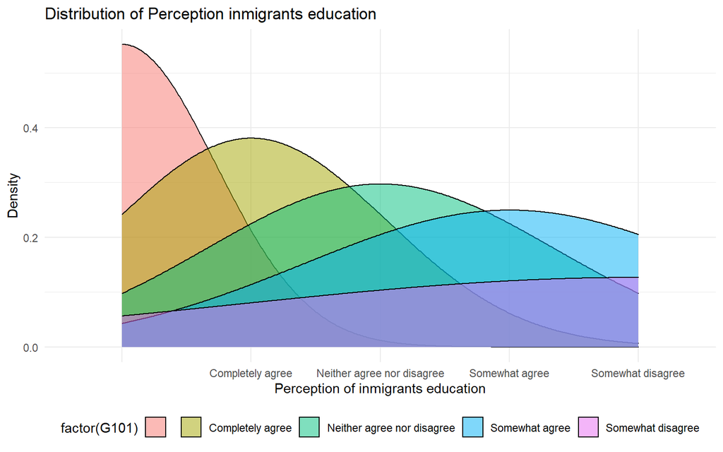

```r
## Descriptives using dummies
ggplot(newdata_dummy, aes(x = G101, fill = factor(G101))) +
  geom_density(alpha = 0.5) +
  theme_minimal() +
  theme(legend.position = "bottom") +
  labs(title = "Distribution of Perception inmigrants education ",
       x = "Perception of inmigrants education",
       y = "Density")
```

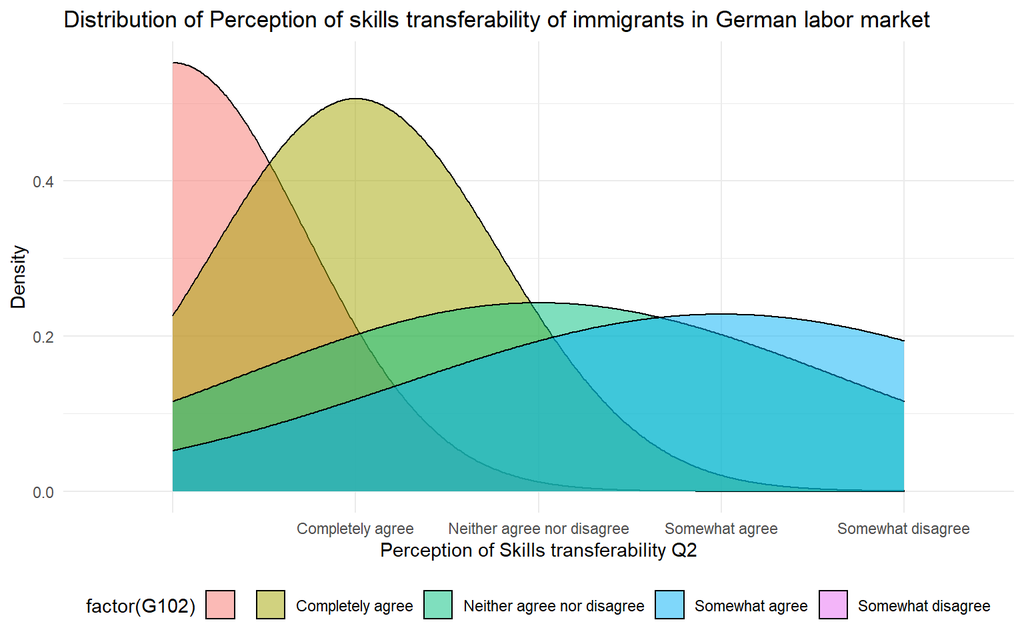

```r
ggsave("distribution_ g101.png")


ggplot(newdata_dummy, aes(x = G102, fill = factor(G102))) +
  geom_density(alpha = 0.5) +
  theme_minimal() +
  theme(legend.position = "bottom") +
  labs(title = "Distribution of Perception of skills transferability of immigrants in German labor market ",
       x = "Perception of Skills transferability Q2",
       y = "Density")
```

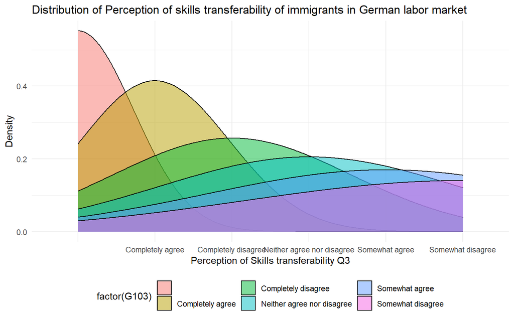

```r
ggsave("distribution_ g102.png")

ggplot(newdata_dummy, aes(x = G103, fill = factor(G103))) +
  geom_density(alpha = 0.5) +
  theme_minimal() +
  theme(legend.position = "bottom") +
  labs(title = "Distribution of Perception of skills transferability of immigrants in German labor market ",
       x = "Perception of Skills transferability Q3",
       y = "Density")
```

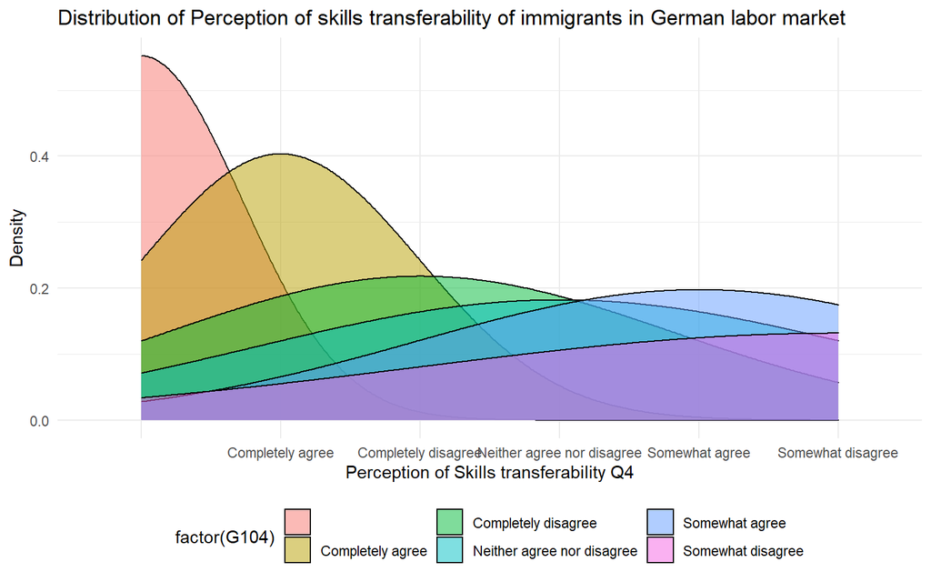

```r
ggsave("distribution_ g103.png")

ggplot(newdata_dummy, aes(x = G104, fill = factor(G104))) +
  geom_density(alpha = 0.5) +
  theme_minimal() +
  theme(legend.position = "bottom") +
  labs(title = "Distribution of Perception of skills transferability of immigrants in German labor market ",
       x = "Perception of Skills transferability Q4",
       y = "Density")
```

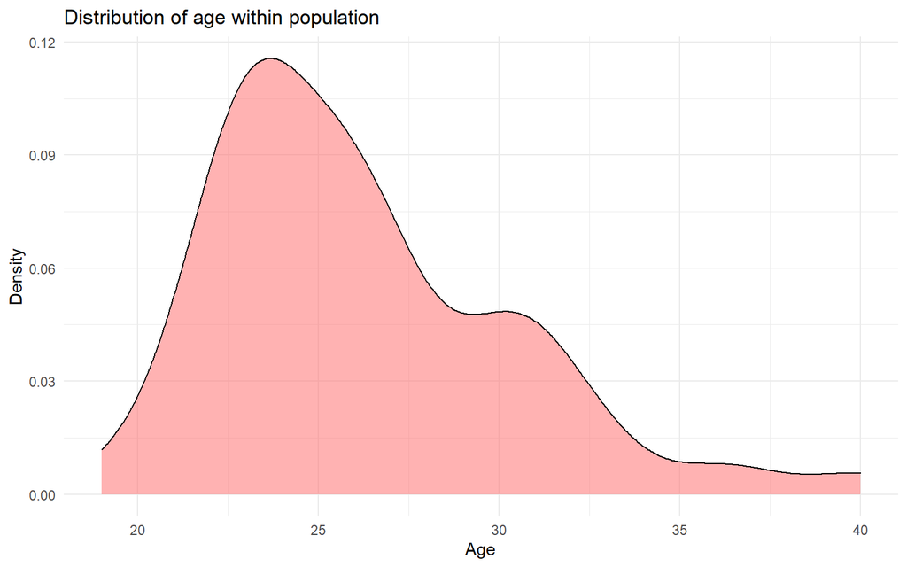

```r
ggsave("distribution_ g104.png")

# distribution of population by age (the only numeric variable)

ggplot(newdata_dummy, aes(x = A101 )) +
  geom_density(alpha = 0.5, fill="#FF6666") +
  theme_minimal() +
  theme(legend.position = "bottom") +
  labs(title = "Distribution of age within population",
       x = "Age",
       y = "Density")
```

```r
ggsave("age.png")
```

A LOT OF ERRORS

# descriptive statistics without dummies

statist <- newdata_dummy %>% select( -A108, -IL02, -A102_Male, -`A102_Non-binary`, - `A102_Prefer not to say`, - `A105_Employed Part-time`,- A105_Unemployed, -europe, -A109_Public, -IL02_CP) labs <- c(“Age”, “Gender”, “Employment type”, “Education level”, “University type”,“Ethnicity”,“Requirements for residency”, “Perception inmmigrants´s education”, “Skills transferability control”,“Skills transferability group 1”,“Skills transferability group 2”)

stats <- sumtable(statist ,labels = labs, summ=c(‘notNA(x)’,“mean(x)”, “median(x)”,“sd(x^2)”, ‘min(x)’,‘max(x)’), summ.names = list(c(‘N’,‘Mean’,“Median”,‘SD’,‘Min’,‘Max’))) write.table(stats, file = “sumstats_d.tex”)

# descriptive statistics with dummies

newd <- newdata_dummy %>% select(A102_Male, `A105_Employed Part-time`, A105_Unemployed, europe, A109_Public)

labs <- c(“Male”, “Employed part-time”,“Unemployed”, “European citizen”, “Public university”) ##ERROR stats_1 <- sumtable(newd ,labels = labs, summ=c(‘notNA(x)’,“mean(x)”, “median(x)”,“sd(x^2)”, ‘min(x)’,‘max(x)’), summ.names = list(c(‘N’,‘Mean’,“Median”,‘SD’,‘Min’,‘Max’))) write.table(stats_1, file = “sumstats_2.tex”)

# balance check

#matchit only accept a treat binomial newdata_dummy$temp<- ifelse(newdata_dummy$IL02==“Group 1”,1,ifelse(newdata_dummy$IL02==“Group 2”,2,0))

#subsetting data to use the dummy newdata_temp <- newdata_dummy[ which(newdata_dummy$temp==2 |newdata_dummy$temp==0),] newdata_temp2 <- newdata_dummy[ which(newdata_dummy$temp2==1| newdata_dummy$temp==0),]

#1:1 NN matching w/ replacement on a logistic regression PS

newdata_temp$cont<- ifelse(newdata_temp$temp==2, 1,0) m.out1 <- matchit(cont~ ind_102 + ind_103 , data = newdata_temp, replace = TRUE)

labs1 <- c(“ST control”, “ST group 1”) s <- summary(m.out1, labels=labs1) capture.output(s, file=“balance_1.tex”)

# including dummies

labs2 <- c(“Perception 1”, “Perception 2”,“Perception 3”, “Perception 4”) summary(m.out1, addlvariables = A102_Male + `A105_Employed Part-time` + A105_Unemployed +europe + A109_Public, labels=labs, file=“balance_1.tex”)

newdata_temp2$cont<- ifelse(newdata_temp$temp==2, 1,0) m.out2 <- matchit(cont~ ind_102 + ind_104, data = newdata_temp2, replace = TRUE)

labs1 <- c(“ST control”, “ST group 2”) s1<- summary(m.out2, labels=labs1) capture.output(s1, file=“balance_2.tex”)

# Regressions

```r
# First: only outcome and treatments

control_model <- lm(G102 ~ dcontrol, data = regressiondata)

treatment1_model <- lm(G102 ~ treatment1, data = regressiondata)

treatment2_model <- lm(G102 ~ treatment2, data = regressiondata)

stargazer::stargazer(control_model, treatment1_model, treatment2_model,
                     type = "latex",
                     report = ("vc*p"),
                     title = "Regressions focused only on the treatments",
                     model.numbers = FALSE,
                     covariate.labels = c("Treated", "Treatment 1", "Treatment 2"),
                     dep.var.labels = "Perceived Skills Transferability",
                     dep.var.caption = "")

# Second: outcome, treatments and sociodemographics
controlvariables_model <- lm(G102 ~ dcontrol + A101 + A102 + A105 + A106 + A107 , data = regressiondata)

stargazer::stargazer(controlvariables_model,
                     type = "latex",
                     report = ("vc*p"),
                     title = "Regression with sociodemographics",
                     model.numbers = FALSE,
                     covariate.labels = c("Treated", "Age", "Male", "Non-binary", "Prefer not to say (Gender)", "Employed Part-time", "Unemployed", "High School", "Master Degree", "Caucasian/White", "East Asian", "Latino or Hispanic", "Other (Ethnicity)", "South Asian", "Two or More (Ethnicity)"),
                     dep.var.labels = "Perceived Skills Transferability",
                     dep.var.caption = "")

# Third: with interactions (german, european, private)
german_model <- lm(G102 ~ dcontrol * dgerman , data = regressiondata)

t1german_model <- lm(G102 ~ treatment1 * dgerman, data = regressiondata)

t2german_model <- lm(G102 ~ treatment2 * dgerman, data = regressiondata)

stargazer::stargazer(german_model, t1german_model, t2german_model,
                     type = "latex",
                     report = ("vc*p"),
                     title = "Regressions with interaction (Germans)",
                     covariate.labels = c("Treated", "Treatment 1", "Treatment 2", "Germans", "Interaction (T/G)", "Interaction (T1/G)", "Interaction (T2/G)"),
                     dep.var.labels = "Perceived Skills Transferability",
                     dep.var.caption = "")

european_model <- lm(G102 ~ dcontrol * deurope , data = regressiondata)

t1EU_model <- lm(G102 ~ treatment1 * deurope, data = regressiondata)

t2EU_model <- lm(G102 ~ treatment2 * deurope, data = regressiondata)

stargazer::stargazer(european_model, t1EU_model, t2EU_model,
                     type = "latex",
                     report = ("vc*p"),
                     title = "Regressions with interaction (UE)",
                     covariate.labels = c("Treated", "Treatment 1", "Treatment 2", "Europeans", "Interaction (T/EU)", "Interaction (T1/EU)", "Interaction (T2/EU)"),
                     dep.var.labels = "Perceived Skills Transferability",
                     dep.var.caption = "")

private_model <- lm(G102 ~ dcontrol * dprivate , data = regressiondata)

t1priv_model <- lm(G102 ~ treatment1 * dprivate, data = regressiondata)

t2priv_model <- lm(G102 ~ treatment2 * dprivate, data = regressiondata)

stargazer::stargazer(private_model, t1priv_model, t2priv_model,
                     type = "latex",
                     report = ("vc*p"),
                     title = "Regressions with interaction (Private University)",
                     covariate.labels = c("Treated", "Treatment 1", "Treatment 2", "Private", "Interaction (T/P)", "Interaction (T1/P)", "Interaction (T2/P)"),
                     dep.var.labels = "Perceived Skills Transferability",
                     dep.var.caption = "")

# Forth: using other outcome
personal_model <- lm(G103 ~ dcontrol, data = regressiondata)

competition_model <- lm(G104 ~ dcontrol, data = regressiondata)

stargazer::stargazer(personal_model, competition_model,
                     type = "latex",
                     report = ("vc*p"),
                     title = "Regressions with Labor Market Concern",
                     model.numbers = FALSE,
                     covariate.labels = c("Treated"),
                     dep.var.labels = "(Personal)", "(General)",
                     dep.var.caption = "")
```